# Homework by 19031

19031

12/29/2019

## Overview

**SC19031** is a simple R packag and it is based on the specific application of the DBSCABN(Density-based spatial clustering of applications with noise) clustering algorithm. It initially classifies the target data and further lists all types of data. Also included in this file are the answers to all assignments by the author when he took the course in statistical calculation.

**A-Homework-2019.09.29**

##Question1

The Rayleigh density [156, Ch. 18] is f(x)= (x*exp(−x<sup>2/(2σ</sup>2)))/σ^2, x≥0,σ>0. Develop an algorithm to generate random samples from a Rayleigh(σ) distri- bution. Generate Rayleigh(σ) samples for several choices of σ > 0 and check that the mode of the generated samples is close to the theoretical mode σ (check the histogram).

##Answer

f(x)=(x*exp(−x<sup>2/(2σ</sup>2)))/σ^2, x≥0,σ>0. F(x)=1-exp(-x^2/(2*σ^2))

x=sqrt(-2*(σ<sup>2)*log(1-F(x))) so 1.Generate u from Unif(0,1). 2.Deliver x =sqrt(-2*(σ</sup>2)*log(1-u))

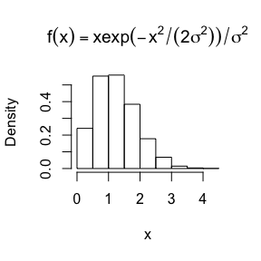

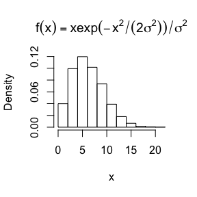

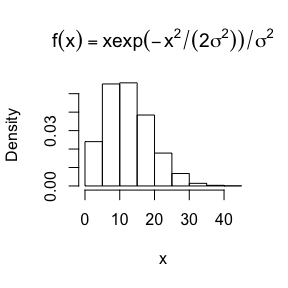

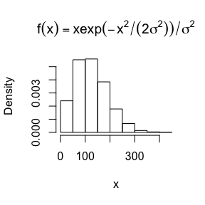

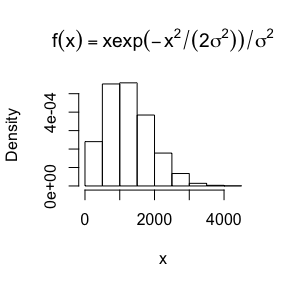

```r
n <- 10000
u <-runif(n)
for(sigma in c(1,5,10,100,1000)){
x<-sqrt(-2*(sigma^2)*log(1-u))#F(x)=1-exp(-x^2/(2*sigma^2)),x>=0
hist(x, prob = TRUE, main= expression(f(x)==x*exp(-x^2/(2*sigma^2))/sigma^2))
}
```

##Question2

Generate a random sample of size 1000 from a normal location mixture. The components of the mixture have N (0, 1) and N (3, 1) distributions with mixing probabilities p1 and p2 = 1 − p1. Graph the histogram of the sample with density superimposed, for p1 = 0.75. Repeat with different values for p1 and observe whether the empirical distribution of the mixture appears to be bimodal. Make a conjecture about the values of p1 that produce bimodal mixtures.

##Answer

1. Generate u ∼ Uniform(0,1).
2. If u ≤ p1 generate x from N(0,1); otherwise generate x from N(3,1).

The following figure corresponds to the histogram generated by P1 with different values

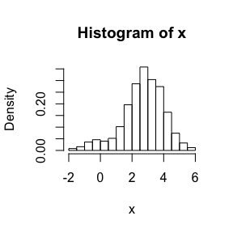

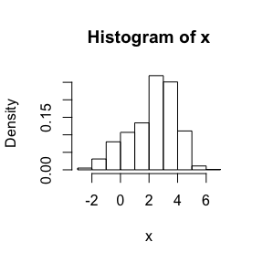

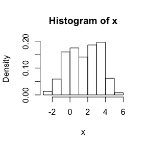

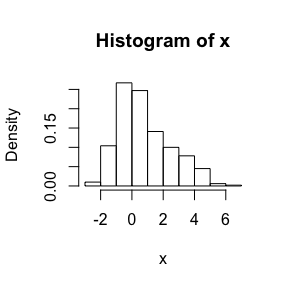

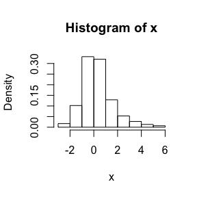

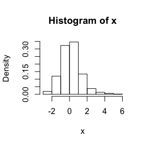

```r
n<-1000
u<-runif(n)
for(p1 in c(0.1,0.25,0.5,0.75,0.9,0.95)){
for (i in 1:n) {
  if(u[i]<p1)#we we accept x
    x[i]<-rnorm(1,0,1)else
      x[i]<-rnorm(1,3,1)
    x<-x[1:n]
  }
hist(x,prob=TRUE)
}
```

##Question3

Write a function to generate a random sample from a Wd(Σ,n) (Wishart) distribution for n > d + 1 ≥ 1, based on Bartlett’s decomposition.

##Answer for n=6,d=3

Suppose M = X’X, where X is an n×d data matrix of a random sample from a Nd(μ,Σ) distribution. Then M has a Wishart distribution with scale matrix Σ and n degrees of freedom, denoted M ∼ Wd(Σ,n)

```r
n<-6
d<-3
T<- matrix(rnorm(n*d), nrow = n, ncol = d)
sigma<-cor(T)
Q<-chol(sigma)
Z<-matrix(rnorm(n*d), nrow = n, ncol = d)
mu<-c(0,0,0)
X <- Z %*% Q + matrix(mu, n, d, byrow = TRUE)
#X is an n×d data matrix of a random sample from a Nd(μ,Σ)
M<-t(X)%*%X#Denote M ∼ Wd(Σ,n)
M
```

```
##           [,1]      [,2]      [,3]
## [1,]  3.595487  2.559468 -2.108064
## [2,]  2.559468  5.257053 -4.485144
## [3,] -2.108064 -4.485144  3.968220
```

**Homework2019-10-11**

##Question1

Compute a Monte Carlo estimate of
$$\int_{0}^{ {\pi} / 3} \sin t d t$$
and compare your estimate with the exact value of the integral.

##Anwser

```r
m <- 1e4
x <- runif(m, min=0, max=pi/3)
theat.hat<-mean(sin(x))*pi/3
print(c(theat.hat,-cos(pi/3)+1))
```

```
## [1] 0.4976739 0.5000000
```

```r
m <- 1e6
x <- runif(m, min=0, max=pi/3)
theat.hat<-mean(sin(x))*pi/3
print(c(theat.hat,-cos(pi/3)+1))
```

```
## [1] 0.5000998 0.5000000
```

Obviously, the larger m is, the closer it is to the true value.

##Question2

5.10 Use Monte Carlo integration with antithetic variables to estimate ∫10e−x1+x2dx and find the approximate reduction in variance as a percentage of the variance without variance reduction.

##Answer

```r
n<-1e4
x<-runif(n,0,1)
theta.hat<-mean(exp(-x)/(1+x^2))
theta.hat
```

```
## [1] 0.5270748
```

```r
thetas<-exp(-x)/(1+x^2)
sd(thetas)
```

```
## [1] 0.2455752
```

```r
se<-sd(thetas)/sqrt(n)
se
```

```
## [1] 0.002455752
```

```r
round(c(theta.hat-1.96*se,theta.hat+1.96*se),3)#The 95% CI of θ (CLT)
```

```
## [1] 0.522 0.532
```

```r
#Antithetic variables
f<-function(u){exp(-u)/(1+u^2)
  }
u <- runif(n)
    MC1<-f(u)
    MC2<-f(1-u) # MC1 and MC2 are negatively correlated
    for (i in 1:n) {
   MC<-numeric(n)

    MC[i]<-(MC1[i]+MC2[i])/2

    }
  c(sd(MC),sd(thetas),(sd(thetas)-sd(MC))/sd(thetas))
```

```
## [1] 0.004929204 0.245575241 0.979927928
```

##Question

Obtain the stratified importance sampling estimate in Example 5.13 and compare it with the result of Example 5.10.

##Answe

```r
M <- 1e6 #number of replicates
k <- 50 #number of strata
r <- M / k #replicates per stratum
N <- 50 #number of times to repeat the estimation
T2 <- numeric(k)
T1<-numeric(k)

estimates <- matrix(0, N, 3)
g<-function(x){
   exp(-x)/(1+x^2)
}
f<-function(x){
  exp(-x)/(1-exp(-1))
}
for (i in 1:N) {
  estimates[i, 1] <- mean(g(runif(M)))
  for (j in 1:k) {
  T2[j] <- mean(g(runif(M/k, (j-1)/k, j/k)))
  # T2 is the stratified sampling


  #Stratified Importance Sampling
  u<-runif(M/k,(j-1)/k, j/k)
  t<- -log(1-(u+j-1)*(1-exp(-1))/k)
  T1[j]<-(mean(g(t)/f(t)/k))
  }
  estimates[i, 2] <- mean(T2)
  estimates[i, 3] <- sum(T1)
}


#Example 5.10
u <- runif(M) #f inverse transform method
x <- - log(1 - u * (1 - exp(-1)))
fg <- g(x) / (exp(-x) / (1 - exp(-1)))
theta.hat <- mean(fg)
se<-var(fg)





apply(estimates, 2, mean)
```

```
## [1] 0.5247831 0.5247972 0.5237855
```

```r
apply(estimates, 2, var)
```

```
## [1] 9.160764e-08 1.859850e-11 1.699394e-15
```

```r
c(se,apply(estimates, 2, var))
```

```
## [1] 9.368484e-03 9.160764e-08 1.859850e-11 1.699394e-15
```

Obviously, compared with the Example 5.10, this method can significantly reduce variance.

**Homework-2019-10-18**

##Question 1

Suppose a 95% symmetric t-interval is applied to estimate a mean, but the sample data are non-normal. Then the probability that the confidence interval covers the mean is not necessarily equal to 0.95. Use a Monte Carlo experiment to estimate the coverage probability of the t-interval for random samples of χ2(2) data with sample size n = 20. Compare your t-interval results with the simulation results in Example 6.4. (The t-interval should be more robust to departures from normality than the interval for variance.)

##ANswer

```r
n<-20
alpha <- 0.05
m<-10000
p<-numeric(m)
for (i in 1:m) {
x<-rchisq(n,2)
UCL<-t.test(x, alternative="two.sided", mu = 2)
p[i] <-UCL$p.value
}
p.hat <- mean(p < alpha)
se.hat <- sqrt(p.hat * (1 - p.hat) / m)
print(c(p.hat, se.hat))
```

```
## [1] 0.080500000 0.002720657
```

```r
1-p.hat
```

```
## [1] 0.9195
```

The confidence interval covers the mean approximate 92% greater than the Example 6.4 77.3%。

##Question 2

Estimate the 0.025, 0.05, 0.95, and 0.975 quantiles of the skewness b1 under normality by a Monte Carlo experiment. Compute the standard error of the estimates from (2.14) using the normal approximation for the density (with exact variance formula). Compare the estimated quantiles with the quantiles of the large sample approximation √b1 ≈ N (0, 6/n).

##Answer

```r
LN<-c(10,20,50,100,300,500,1000)
quant<-c(0.025,0.05,0.95,0.975)
m<-1e4
sk<-numeric(m)#computes the sample skewness coeff.

f<-function(x){#Normal distribution density
  exp(-(x^2)/2)/sqrt(2*pi)
}
est1<-matrix(0,length(LN),4,dimnames=list(c(LN),c(quant)))
est2<-matrix(0,length(LN),4,dimnames=list(c(LN),c(quant)))
est3<-matrix(0,length(LN),4,dimnames=list(c(LN),c(quant)))

for (j in 1:length(LN) ) {
  n<-LN[j]


for (i in 1:m) {
  x<-rnorm(n)
  xbar<-mean(x)
  m3<-mean((x-xbar)^3)
  m2<- mean((x-xbar)^2)
  sk[i]<-m3/m2^1.5
}

  cv<- qnorm(c(0.025,0.05,0.95,0.975), 0, 6/n)
 est1[j,] <- c(quantile(sk,c(0.025,0.05,0.95,0.975)))
 est2[j,] <- c(cv)

}



for (i in 1:length(LN) ){#Compute the standard error of the estimates
  n<-LN[i]
  for (j in 1:4) {
 quant<-c(0.025,0.05,0.95,0.975)
  est3[i,j] <-  quant[j]*(1-quant[j])/n/(f(est1[i,j])^2)

  }
}

est1 #The estimates of quantiles by Monte Carlo experiment.
```

```
##           0.025       0.05      0.95     0.975
## 10   -1.1671517 -0.9647440 0.9388118 1.1675159
## 20   -0.9734396 -0.7924789 0.7794992 0.9663383
## 50   -0.6510205 -0.5439515 0.5366693 0.6431572
## 100  -0.4745722 -0.3923126 0.3840223 0.4637107
## 300  -0.2699513 -0.2262358 0.2313078 0.2787965
## 500  -0.2141641 -0.1806977 0.1805033 0.2171866
## 1000 -0.1525791 -0.1268952 0.1293169 0.1540993
```

```r
est2#The quantiles from  √b1 ≈ N (0, 6/n)
```

```
##            0.025         0.05        0.95      0.975
## 10   -1.17597839 -0.986912176 0.986912176 1.17597839
## 20   -0.58798920 -0.493456088 0.493456088 0.58798920
## 50   -0.23519568 -0.197382435 0.197382435 0.23519568
## 100  -0.11759784 -0.098691218 0.098691218 0.11759784
## 300  -0.03919928 -0.032897073 0.032897073 0.03919928
## 500  -0.02351957 -0.019738244 0.019738244 0.02351957
## 1000 -0.01175978 -0.009869122 0.009869122 0.01175978
```

```r
est3#  Standard error of the estimates
```

```
##             0.025         0.05         0.95        0.975
## 10   0.0598052280 0.0756980638 0.0720520879 0.0598561068
## 20   0.0197526456 0.0279634215 0.0273986422 0.0194824184
## 50   0.0046797269 0.0080242407 0.0079613435 0.0046323452
## 100  0.0019183849 0.0034810912 0.0034587585 0.0018989337
## 300  0.0005491006 0.0010470817 0.0010495144 0.0005517723
## 500  0.0003206815 0.0006167141 0.0006166708 0.0003210999
## 1000 0.0001567599 0.0003032960 0.0003034842 0.0001568330
```

**Homework-2019-11-01**

##QUestion1

Estimate the power of the skewness test of normality against symmetric Beta(α, α) distributions and comment on the results. Are the results different for heavy-tailed symmetric alternatives such as t(ν)?

##Answer

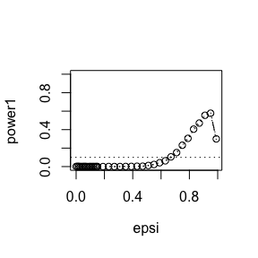

```r
sk <- function(x) {
#computes the sample skewness coeff.
xbar <- mean(x)
m3 <- mean((x - xbar)^3)
m2 <- mean((x - xbar)^2)
return( m3 / m2^1.5 )
}
alpha <- 0.05
n <- 100
m <- 2500
epsi <- c(seq(0, .15, .01), seq(.15, 1, .04))
N <- length(epsi)
power1 <-numeric(N)
#critical value for the skewness test
cv <- qnorm(1-alpha/2, 0, sqrt(6*(n-2) / ((n+1)*(n+3))))
for (j in 1:N) { #for each epsilon
  pe <- epsi[j]
skt <-numeric(m)
for (i in 1:m) { #for each replicate
sigm <- sample(c(1, 20), replace = TRUE, size = n, prob = c(1-pe, pe))
x <- rbeta(n, sigm, sigm)

skt[i] <- as.integer(abs(sk(x)) >= cv)
}

        power1[j] <- mean(skt)
}
#plot power vs epsi
plot(epsi, power1, type = "b",
xlab = bquote(epsi), ylim = c(0,1))
abline(h =0.1, lty = 3)
se <- sqrt(power1 * (1-power1) / m)
lines(epsi, power1+se, lty = 3)
lines(epsi, power1-se, lty = 3)
```

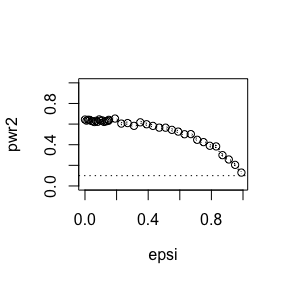

```r
##t(v)
pwr2<-numeric(N)
for (j in 1:N) { #for each epsi
 pe <- epsi[j]
skt1 <-numeric(m)
for (i in 1:m) { #for each replicate
tfre <- sample(c(3, 20), replace = TRUE, size = n, prob = c(1-pe, pe))
x <- rt(n, tfre)

skt1[i] <- as.integer(abs(sk(x)) >= cv)
}

        pwr2[j] <- mean(skt1)
}

plot(epsi, pwr2, type = "b",
xlab = bquote(epsi), ylim = c(0,1))
abline(h = 0.1, lty = 3)
se <- sqrt(pwr2 * (1-pwr2) / m) #add standard errors
lines(epsi, pwr2+se, lty = 3)
lines(epsi, pwr2-se, lty = 3)
```

##Question2

Use Monte Carlo simulation to investigate whether the empirical Type I er- ror rate of the t-test is approximately equal to the nominal significance level α, when the sampled population is non-normal. The t-test is robust to mild departures from normality. Discuss the simulation results for the cases where the sampled population is (i) χ2(1), (ii) Uniform(0,2), and (iii) Exponen- tial(rate=1). In each case, test H0 : μ = μ0 vs H0 :
$$μ \neq μ0$$
, where μ0 is the mean of χ2(1), Uniform(0,2), and Exponential(1), respectively.

##Answer

```r
#sample from χ2(1)
#  H0:  u=1
u<-1
n<-10000
m<-100
alpha<-0.05  ## confidence level of the interval.
qt1<-qt(1-alpha/2,m-1)
pow<-numeric(n)
for (i in 1:n) {
 x<-rchisq(m,1)
 Test<-sqrt(m)*(mean(x)-u)/sd(x)
 pow[i]<-as.integer(abs(Test)>qt1)

}
mean(pow)
```

```
## [1] 0.0629
```

```r
#sample from U(0,2)
#  H0 :  u=1

pow1<-numeric(n)
for (i in 1:n) {
  x<-runif(m,0,2)
 Test<-sqrt(m)*(mean(x)-u)/sd(x)
 pow1[i]<-as.integer(abs(Test)>qt1)


}
mean(pow1)
```

```
## [1] 0.0476
```

```r
#sample from Exponential(1)
## H0  :  u=1
pow2<-numeric(n)
for (i in 1:n) {
  x<-rexp(m,1)
  Test<-sqrt(m)*(mean(x)-u)/sd(x)
 pow2[i]<-as.integer(abs(Test)>qt1)


}
mean(pow2)
```

```
## [1] 0.0559
```

In above three distributions,the t-test is robust to mild departures from normality.

##Question3

1. The problem is H0 : p1=p2 VS H1 :
   $$p1 \neq p2$$
   Adopt binomial distribution b(n1,p1) and b(n2,p2) to gernerate n1+n2 samples, use the mean value of b(n1,p1) to estimate p1 and use the mean value of b(n2,p2) to estimate p2.

Paired-test is a better way to test the hypothesis.

3. The p1 and p2 that the question provide is close to the real values of two methods.

```r
## Z-test
n<-10000
m<-100
alpha<-0.05
p1<-0.651
p2<-0.676
qt1<-qnorm(1-alpha/2,0,1)
pow1<-numeric(n)
for (i in 1:n){
  x<-rbinom(m,1,p1)
  pow1[i]<-as.integer(mean(x)<(p2-qt1*sqrt(p2*(1-p2)/m)))+as.integer(mean(x)>(p2+qt1*sqrt(p2*(1-p2)/m)))
}
mean(pow1)# approximately equal to0.09
```

```
## [1] 0.0906
```

```r
## Two sample test
pow3<-numeric(n)
tq1<-qt(1-alpha/2,2*m-1)
for (i in 1:n) {
  x<-rbinom(m,1,p1)
  y<-rbinom(m,1,p2)
  sw<-(m-1)*(var(x)+var(y))/(m+m-2)
  Test<-(mean(x)-mean(y))/sqrt(sw*(1/m+1/m))
  pow3[i]<-as.integer(Test>tq1)
}
mean(pow3)
```

```
## [1] 0.0107
```

```r
m1<-100
m2<-50
pow31<-numeric(n)
for (i in 1:n) {
  x<-rbinom(m1,1,p1)
  y<-rbinom(m2,1,p2)
  sw<-((m1-1)*var(x)+(m2-1)*var(y))/(m1+m2-2)
  Test<-(mean(x)-mean(y))/sqrt(sw*(1/m1+1/m2))
  pow31[i]<-as.integer(Test>tq1)
}
mean(pow31)
```

```
## [1] 0.0124
```

```r
## Paired-test
tq2<-qt(1-alpha/2,2*m-1)
pow4<-numeric(n)
for (i in 1:n) {
  x<-rbinom(m,1,p1)
  y<-rbinom(m,1,p2)
  Test<-(mean(x)-mean(y))/sqrt((var(x)+var(y))/2/(n/2))
  pow4[i]<-as.integer(Test>tq2)
}
mean(pow4)
```

```
## [1] 0.2753
```

```r
##  Z-test  compare with above
n<-10000
m<-100
alpha<-0.05
p1<-0.676
p2<-0.651
qt1<-qnorm(1-alpha/2,0,1)
pow2<-numeric(n)
for (i in 1:n){
  x<-rbinom(m,1,p1)
  pow2[i]<-as.integer(mean(x)<(p2-qt1*sqrt(p2*(1-p2)/m)))+as.integer(mean(x)>(p2+qt1*sqrt(p2*(1-p2)/m)))
}
mean(pow2)# approximately equal to0.07
```

```
## [1] 0.0762
```

**Homework-2019-11-08**

##Question1

Efron and Tibshirani discuss the scor (bootstrap) test score data on 88 students who took examinations in five subjects [84, Table 7.1], [188, Table 1.2.1]. The first two tests (mechanics, vectors) were closed book and the last three tests (algebra, analysis, statistics) were open book. Each row of the data frame is a set of scores (xi1,…,xi5) for the ith student. Use a panel display to display the scatter plots for each pair of test scores. Compare the plot with the sample correlation matrix. Obtain bootstrap estimates of the standard errors for each of the following estimates: ρˆ12 = ρˆ(mec, vec), ρˆ34 = ρˆ(alg, ana), ρˆ35 = ρˆ(alg, sta), ρˆ45 = ρˆ(ana, sta).

##Answer

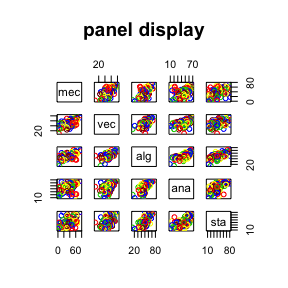

```r
library(bootstrap)
data(scor)
pairs(scor,panel = points,main="panel display",col = c("red", "green3", "blue","yellow","dark red"))
```

```r
cor(scor)## Correlation matrix
```

```
##           mec       vec       alg       ana       sta
## mec 1.0000000 0.5534052 0.5467511 0.4093920 0.3890993
## vec 0.5534052 1.0000000 0.6096447 0.4850813 0.4364487
## alg 0.5467511 0.6096447 1.0000000 0.7108059 0.6647357
## ana 0.4093920 0.4850813 0.7108059 1.0000000 0.6071743
## sta 0.3890993 0.4364487 0.6647357 0.6071743 1.0000000
```

```r
n<-length(scor$mec)
p12head<-p34head<-p35head<-p45head<-numeric(n)
B<-1000

for (b in 1:B) {
  MEC<-sample(scor$mec,n,replace=TRUE)
  VEC<-sample(scor$vec,n,replace=TRUE)
  ALG<-sample(scor$alg,n,replace=TRUE)
  ANA<-sample(scor$ana,n,replace=TRUE)
  STA<-sample(scor$sta,n,replace=TRUE)

  SCOR<-cbind(MEC,VEC,ALG,ANA,STA)
  p12head[b]<-cor(SCOR)[1,2]
  p34head[b]<-cor(SCOR)[3,4]
  p35head[b]<-cor(SCOR)[3,5]
  p45head[b]<-cor(SCOR)[4,5]
}
se12<-sd(p12head)
se34<-sd(p34head)
se35<-sd(p35head)
se45<-sd(p45head)
c(se12,se34,se35,se45)
```

```
## [1] 0.1048289 0.1083701 0.1090170 0.1133850
```

Conclusion,the more discrete the distribution of points, the smaller the correlation coefficient of two tests.

Repeat Project 7.A for the sample skewness statistic. Compare the coverage rates for normal populations (skewness 0) and χ2(5) distributions (positive skewness).

7.A Conduct a Monte Carlo study to estimate the coverage probabilities of the standard normal bootstrap confidence interval, the basic bootstrap confidence interval, and the percentile confidence interval. Sample from a normal population and check the empirical coverage rates for the sample mean. Find the proportion of times that the confidence intervals miss on the left, and the porportion of times that the confidence intervals miss on the right.

## Answer

```r
library(boot)
sk <- function(data,ind) {
  x<-data[ind]
xbar <- mean(x)
m3 <- mean((x - xbar)^3)
m2 <- mean((x - xbar)^2)
return( m3 / m2^1.5 )
}

n<-50

mu1<-0
mu2<-4/sqrt(10)#THe skewness of χ2(5) distributions
B<-1000
ci.norm1<-ci.basic1<-ci.perc1<-matrix(0,B,2)
ci.norm2<-ci.basic2<-ci.perc2<-matrix(0,B,2)
for (i in 1:B) {
  X<-rnorm(n)
  Y<-rchisq(n,5)
  boot.obj1<-boot(X,sk,R=2000)
  boot.obj2<-boot(Y,sk,R=2000)
  CI1<-boot.ci(boot.obj1,conf = 0.95,type =c ("norm","basic","perc"))
  CI2<-boot.ci(boot.obj2,conf = 0.95,type = c("norm","basic","perc"))
ci.norm1[i,]<-CI1$norm[2:3]
ci.basic1[i,]<-CI1$basic[4:5]
ci.perc1[i,]<-CI1$percent[4:5]

ci.norm2[i,]<-CI2$norm[2:3]
ci.basic2[i,]<-CI2$basic[4:5]
ci.perc2[i,]<-CI2$percent[4:5]


}

Ncix1<-mean(ci.norm1[,2]<=mu1)
Bcix1<-mean(ci.basic1[,2]<=mu1 )
Pcix1<-mean(ci.perc1[,2]<=mu1)
Ncix2<-mean(ci.norm1[,1]>=mu1)
Bcix2<-mean(ci.basic1[,1]>=mu1 )
Pcix2<-mean(ci.perc1[,1]>=mu1)
Ncix<-Ncix1+Ncix2
Bcix<-Bcix1+Bcix2
Pcix<-Pcix1+Pcix2

Nciy1<-mean(ci.norm2[,2]<=mu2)
Bciy1<-mean(ci.basic2[,2]<=mu2)
Pciy1<-mean(ci.perc2[,2]<=mu2)
Nciy2<-mean(ci.norm2[,1]>=mu2)
Bciy2<-mean(ci.basic2[,1]>=mu2 )
Pciy2<-mean(ci.perc2[,1]>=mu2)
Nciy<-Nciy1+Nciy2
Bciy<-Bciy1+Bciy2
Pciy<-Pciy1+Pciy2



rnames<-c("right","left","sum")
cnames<-c("Norm","Basci","Perc")

matrix(c(Ncix1,Ncix2,Ncix,Bcix1,Bcix2,Bcix,Pcix1,Pcix2,Pcix),3,3,dimnames=list(rnames,cnames))
```

```
##        Norm Basci  Perc
## right 0.045 0.054 0.022
## left  0.045 0.054 0.026
## sum   0.090 0.108 0.048
```

```r
##"Right"is meaning the confidence intervals miss on the right.
matrix(c(Nciy1,Nciy2,Nciy,Bciy1,Bciy2,Bciy,Pciy1,Pciy2,Pciy),3,3,dimnames=list(rnames,cnames))
```

```
##        Norm Basci  Perc
## right 0.230 0.239 0.283
## left  0.022 0.052 0.000
## sum   0.252 0.291 0.283
```

```r
cp1<-c(1-Ncix,1-Bcix,1-Pcix)
cp2<-c(1-Nciy,1-Bciy,1-Pciy)

list(cp1,cp2)#Coverage probabilities.
```

```
## [[1]]
## [1] 0.910 0.892 0.952
##
## [[2]]
## [1] 0.748 0.709 0.717
```

**Homework-2019-11-15**

##Question1

7.8 Refer to Exercise 7.7. Obtain the jackknife estimates of bias and standard error of θˆ.

##Answer

```r
library("bootstrap")
data("scor")
n<-length(scor$mec)
values<-eigen(cov(scor))$values
theats<-values[1]/sum(values)
theta.jack<-numeric(n)
for (i in 1:n) {
  Scor<-scor[-i,]
  val<-eigen(cov(Scor))$values
  theta.jack[i]<-val[1]/sum(val)
}
bias <- (n - 1) * (mean(theta.jack) - theats)
se.jack <- sqrt((n-1)*mean((theta.jack-theats)^2))
c(bias,se.jack)
```

```
## [1] 0.001069139 0.049552440
```

##Question2

7.10 In Example 7.18, leave-one-out (n-fold) cross validation was used to select the best fitting model. Repeat the analysis replacing the Log-Log model with a cubic polynomial model. Which of the four models is selected by the cross validation procedure? Which model is selected according to maximum adjusted R2?

##Answe

```r
library(DAAG)
```

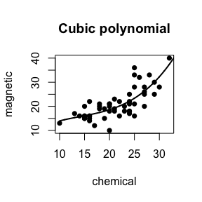

```r
data(ironslag)
n <- length(ironslag$magnetic)
magnetic<-ironslag$magnetic
chemical<-ironslag$chemical

a <- seq(10, 40, 0.01)
L4<-lm(magnetic ~ chemical+I(chemical^2)+I(chemical^3))$coef

plot(chemical, magnetic, main="Cubic polynomial", pch=16)
yhat<-L4[1] +L4[2]*a+L4[3]*a^2+L4[4]*a^3
lines(a, yhat,lwd=2)
```

```r
e1 <- e2 <- e3 <- e4 <- numeric(n)

for (i in 1:n) {
        y <- magnetic[-i]
        x <- chemical[-i]

        #For linear model.
        J1 <- lm(y ~ x)
        yhat1 <- J1$coef[1] + J1$coef[2] * chemical[i]
        e1[i] <- magnetic[i] - yhat1

        ##For quadratic model.
        J2 <- lm(y ~ x + I(x^2))
        yhat2 <- J2$coef[1] + J2$coef[2] * chemical[i] +J2$coef[3] * chemical[i]^2
        e2[i] <- magnetic[i] -yhat2

        ##For exponential  model.
        J3<-lm(log(y)~x)
        logyhat<-J3$coef[1]+J3$coeff[2]*chemical[i]
        yhat3<-exp(logyhat)
        e3[i]<-magnetic[i]-yhat3


         ##For cubic polynomial model.
        J4<-lm(y~ x+I(x^2)+I(x^3))$coef
        yhat4 <- J4[1] + J4[2] * chemical[i] +
 J4[3] * chemical[i]^2+J4[4]*chemical[i]^3
        e4[i]<-magnetic[i]-yhat4
}
SStot<-sum((magnetic-mean(magnetic))^2)
SSres1<-sum(e1^2)
SSres2<-sum(e2^2)
SSres3<-sum(e3^2)
SSres4<-sum(e4^2)
R1<-1-SSres1/SStot
R2<-1-SSres2/SStot
R3<-1-SSres3/SStot
R4<-1-SSres4/SStot
c(mean(e1^2), mean(e2^2), mean(e3^2), mean(e4^2))
```

```
## [1] 19.55644 17.85248 18.44188 18.17756
```

```r
c(R1,R2,R3,R4)
```

```
## [1] 0.4977780 0.5415370 0.5264007 0.5331886
```

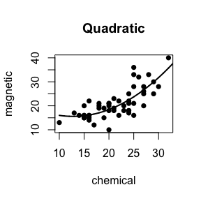

```r
L2 <- lm(magnetic ~ chemical + I(chemical^2))

plot(chemical, magnetic, main="Quadratic", pch=16)
yhat2 <- L2$coef[1] + L2$coef[2] * a + L2$coef[3] * a^2

lines(a, yhat2, lwd=2)
```

```r
L2
```

```
##
## Call:
## lm(formula = magnetic ~ chemical + I(chemical^2))
##
## Coefficients:
##   (Intercept)       chemical  I(chemical^2)
##      24.49262       -1.39334        0.05452
```

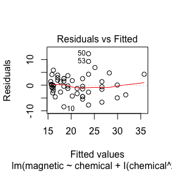

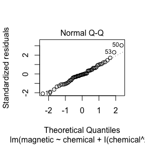

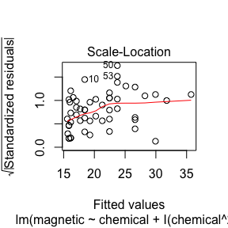

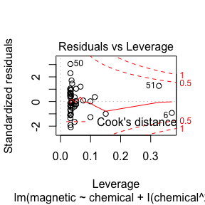

```r
##The fitted regression equation for Model 2 is
#Yˆ = 24.49262 − 1.39334X + 0.05452X
plot(L2)
```

Conclusion，according to the prediction error criterion or according to maximum adjusted R2, Model 2, the quadratic model, would be the best fit for the data.

**Homework-2019-11-22**

##Question1

8.3 The Count 5 test for equal variances in Section 6.4 is based on the maximum number of extreme points. Example 6.15 shows that the Count 5 criterion is not applicable for unequal sample sizes. Implement a permutation test for equal variance based on the maximum number of extreme points that applies when sample sizes are not necessarily equal.

##Answer

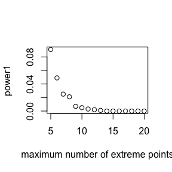

```r
## Fixed sample size with different the maximum number of extreme points.
n<-50
m<-60
N<-999
x<-rnorm(n)
y<-rnorm(m)
ep<-5:20
power1<-numeric(16)
count5test <- function(x, y,ep) {
X <- x - mean(x)
Y <- y - mean(y)
outx <- sum(X > max(Y)) + sum(X < min(Y))
outy <- sum(Y > max(X)) + sum(Y < min(X))
# return 1 (reject) or 0 (do not reject H0)
return(as.integer(max(c(outx, outy)) > ep))
}
for (j in 1:16) {
expoint<-ep[j]
t0<-count5test(x,y,expoint)
z<-c(x,y)
L<-length(z)
K<-1:L
p<-numeric(N)
for (i in 1:N) {
  k<-sample(K,n,replace = FALSE)
  x1<-z[k]
  y1<-z[-k]
  p[i]<-count5test(x1,y1,expoint)
}

power1[j]<-mean(c(t0,p))
}


## Fixed maximum number of extreme points with different sample size
n1<-c(seq(40,300,20))
m1<-c(seq(60,320,20))
N1<-length(n1)
power2<-numeric(N1)
for (j in 1:N1) {
n2<-n1[j]
m2<-m1[j]
x<-rnorm(n2)
y<-rnorm(m2)
t0<-count5test(x,y,5)
z<-c(x,y)
L<-length(z)
K<-1:L
p<-numeric(N)
for (i in 1:N) {
  k<-sample(K,n,replace = FALSE)
  x1<-z[k]
  y1<-z[-k]
  p[i]<-count5test(x1,y1,5)

}
power2[j]<-mean(c(t0,p))
}
plot(ep,power1,xlab = "maximum number of extreme points")
```

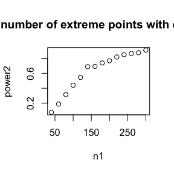

```r
plot(n1,power2,main = "Fixed maximum number of extreme points with different sample size",)
```

Conclusion,the maximum number of extreme points is very important in permutation test.As the number of samples size increases，the occurrence of maximum number of extreme points will increase, so we should increase the initial value of maximum number of extreme points. Similarly, in a fixed sample size, the larger the accident value assigned to the maximum number of extreme point, the smaller the point power function in permutation test.

Therefore, finding a suitable initial value of the maximum number of extreme points is particularly important.

##Question2

Power comparison (distance correlation test versus ball covariance test) 1.Model1: Y =X/4+e 2.Model2: Y =X/4×e 3.X ∼ N(02, I2), e ∼ N(02, I2), X and e are independent.

##Answer

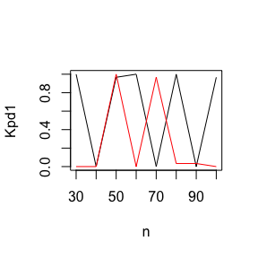

```r
#First,generate sample from Model1 and Model2
library("ks")
library("boot")
library(Ball)



Akl <- function(x) {
d <- as.matrix(dist(x))
m <- rowMeans(d)
M <- mean(d)
a <- sweep(d, 1, m)
b <- sweep(a, 2, m)
return(b + M)
}

dCov <- function(x, y) {
x <- as.matrix(x)
y <- as.matrix(y)
n <- nrow(x)
m <- nrow(y)
if (n != m || n < 2) stop("Sample sizes must agree")
if (! (all(is.finite(c(x, y)))))
stop("Data contains missing or infinite values")

A <- Akl(x)
B <- Akl(y)
dCov <- sqrt(mean(A * B))
dCov
}

ndCov2 <- function(z, ix, dims) {
#dims contains dimensions of x and y
p <- dims[1]
q1 <- dims[2] + 1
d <- p + dims[2]
x <- z[ , 1:p] #leave x as is
y <- z[ix, q1:d] #permute rows of y
return(nrow(z) * dCov(x, y)^2)
}
alpha<-0.05
B<-30##The larger the sample value is, the better the effect will be.
n<-seq(30,100,10)##The larger the sample value is, the better the effect will be.
K<-length(n)

Bpb1<-Bpb2<-Bpb3<-Bpd1<-Bpd2<-Bpd3<-numeric(B)
Kpb1<-Kpb2<-Kpb3<-Kpd1<-Kpd2<-Kpd3<-numeric(K)
for (k in 1:K) {
  n1<-n[k]

for (b in 1:B) {
x1<-rmvnorm.mixt(n1,mus = c(0,0),Sigmas = diag(2))
e1<-rmvnorm.mixt(n1,mus = c(0,0),Sigmas = diag(2))
y1<-x1/4+e1
y2<-(x1/4) * e1
z1<-cbind(x1,y1)
z2<-cbind(x1,y2)
z3<-cbind(y1,y2)
boot.obj1 <- boot(data = z1, statistic = ndCov2, R = 100,
sim = "permutation", dims = c(2, 2))##The larger the sample value is, the better the effect will be.
tb1 <- c(boot.obj1$t0, boot.obj1$t)
Bpd1[b]<-mean(tb1>= boot.obj1$t0)
p.ball1 <- bcov.test(z1[,1:2],z1[,3:4],R=100)$p.value
Bpb1[b]<-p.ball1
boot.obj2 <- boot(data = z2, statistic = ndCov2, R = 100,
sim = "permutation", dims = c(2, 2))
tb2 <- c(boot.obj2$t0, boot.obj2$t)
Bpd2[b]<-mean(tb2>= boot.obj2$t0)
p.ball2 <- bcov.test(z2[,1:2],z2[,3:4],R=100)$p.value
Bpb2[b]<-p.ball2
boot.obj3 <- boot(data = z3, statistic = ndCov2, R = 100,
sim = "permutation", dims = c(2, 2))
tb3 <- c(boot.obj3$t0, boot.obj3$t)
Bpd3[b]<-mean(tb3>= boot.obj3$t0)
p.ball3 <- bcov.test(z3[,1:2],z3[,3:4],R=100)$p.value
Bpb3[b]<-p.ball3
}
 Kpd1[k]<- mean(Bpd1<alpha)
 Kpd2[k]<- mean(Bpd2<alpha)
 Kpd3[k]<- mean(Bpd3<alpha)
 Kpb1[k]<- mean(Bpb1<alpha)
 Kpb2[k]<- mean(Bpb1<alpha)
 Kpb3[k]<- mean(Bpb1<alpha)
}
##Test the independant of x1 and y1 .
plot(n,Kpd1,type = "l")
lines(n,Kpb1,col=2,type = "l")
```

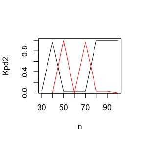

```r
##Test the independant of x1 and y2 .
plot(n,Kpd2,type = "l")
lines(n,Kpb2,type="l" ,col=2)
```

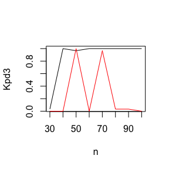

```r
##Test the independant of y1 and y1 .
plot(n,Kpd3,type = "l")
lines(n,Kpb3,type="l",col=2)
```

```r
##The larger the sample value is, the better the effect will be.
```

**Homework-2019-11-29**

##Question

Implement a random walk Metropolis sampler for generating the standard Laplace distribution (see Exercise 3.2). For the increment, simulate from a normal distribution. Compare the chains generated when different variances are used for the proposal distribution. Also, compute the acceptance rates of each chain.

##Answer

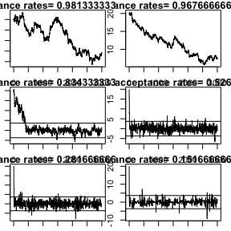

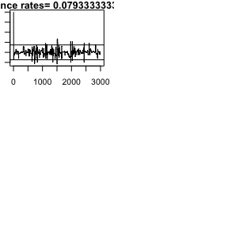

```r
f <- function(x) {
  1/2*exp(-abs(x))
}
#g <- function(x,sigma) {dnorm(x,sigma)}
rw.Metropolis<-function(sigma,x0,N){
  x<-numeric(N)
  x[1]<-x0
  u<-runif(N)
   k <- 0
  for (i in 2:N) {
    y <- rnorm(1, x[i-1], sigma)
    if (u[i] <= ( f(y) / f(x[i-1]) ))
     x[i] <- y
    else {
     x[i] <- x[i-1]
     k <- k + 1
   }
  }
return(list(x=x, k=k))
}
sigma<-c(0.05,0.1,0.5,2,5,10,20)
B<-length(sigma)
N<-3000
x0<-20
par(mfrow=c(3,2))
for (i in 1:B) {
Rw<-rw.Metropolis(sigma[i],x0,N)
k<-Rw$k
par(mar=c(1,1,1,1))
plot(1:N,Rw$x,type="l",xlab = paste("sigma=",sigma[i]),main=paste("acceptance rates=",(N-k)/N))
   abline(h=c(log(.05/2),-log(.05/2)))

}
```

Looking at the convergence rate and acceptance rate,we can choose $\sigma=2$ .

**Homework-2019-12-06**

##Question 1

11.1 The natural logarithm and exponential functions are inverses of each other, so that mathematically log(exp x) = exp(log x) = x. Show by example that this property does not hold exactly in computer arithmetic. Does the identity hold with near equality? (See all.equal.)

##Answer

```r
x<-1:50
y1<-exp(x)
y2<-log(x)
isTRUE(all.equal(log(y1), exp(y2)))
```

```
## [1] TRUE
```

```r
isTRUE(all.equal(log(y1),x ))
```

```
## [1] TRUE
```

```r
isTRUE(all.equal(x, exp(y2)))
```

```
## [1] TRUE
```

```r
identical(log(y1),exp(y2))
```

```
## [1] FALSE
```

```r
isTRUE(all.equal(log(y1) -exp(y2),0))
```

```
## [1] FALSE
```

```r
isTRUE(all.equal(log(y1)-x ,0))
```

```
## [1] FALSE
```

```r
isTRUE(all.equal(x-exp(y2),0))
```

```
## [1] FALSE
```

##Question 2

11.5 Write a function to solve the equation

$$\frac{2\Gamma(\frac{k}{2})}{\sqrt(\pi(k-1)) \Gamma(\frac{k-1}{2})} \int_{0}^{c_{k-1}}(1+\frac{u^{2}}{k-1})^{-k/2}du= \frac{2\Gamma(\frac{k+1}{2})}{\sqrt(\pi k) \Gamma(\frac{k-1}{2})} \int_{0}^{c_{k}}(1+\frac{u^{2}}{k})^{-(k+1)/2}du$$
for a, where
$$c_{k} = \sqrt\frac{a^{2}k}{k+1-a^{2}}$$
Compare the solutions with the points A(k) in Exercise 11.4. 11.4 Find the intersection points A(k) in (0, $ k $) of the curves
$$S_{k-1}(a)=P(t(k-1) > \sqrt(\frac{a^{2}(k-1)}{k-a^{2}}))$$
and
$$S_{k}(a)=P(t(k) > \sqrt(\frac{a^{2}k}{k+1-a^{2}}))$$

for k = 4 : 25, 100, 500, 1000, where t(k) is a Student t random variable with k degrees of freedom. (These intersection points determine the critical values for a t-test for scale-mixture errors proposed by Sz ́ekely [260].)

##Answer

```r
K1<-c(4:25,100,500,1000)
B1<-length(K1)
eps <- .Machine$double.eps^0.25
root1<-numeric(B1)

for (b in 1:B1) {
  k<-K1[b]
  b0<-eps
b1 <- sqrt(k) - eps



 root1[b]<-uniroot(function(a){
  z1<-sqrt(a^2*(k-1)/(k-a^2))
  z2<-sqrt(a^2*k/(k+1-a^2))
  gx<-pt(z1,k-1,lower.tail = FALSE)-pt(z2,k,lower.tail = FALSE)
  return(gx)
},interval = c(b0, b1))$root
}
root1
```

```
##  [1]  1.492103  1.533549  1.562768  1.584421  1.601196  1.614530  1.625368
##  [8]  1.634404  1.642024  1.648540  1.654170  1.659099  1.663452  1.667288
## [15]  1.670736  1.673840  1.676588  1.679139  1.681461  1.683589  1.685545
## [22]  1.687347  1.720598 22.360558 31.622655
```

```r
####################################################################################################################
K<-c(4:25,100)
B<-length(K)
root2<-numeric(B)

for (b in 1:B) {
  k<-K[b]
  f<-function(a){
  z1<-sqrt(a^2*(k-1)/(k-a^2))
  z2<-sqrt(a^2*k/(k+1-a^2))
  f1<-function(x){
    gamma(k/2)*(1+(z1*x)^2 /(k-1))^(-k/2) *z1/gamma((k-1)/2)/sqrt((k-1)*pi)-gamma((k+1)/2)*(1+(z2*x)^2 /k)^(-(k+1)/2) *z2/gamma(k/2)/sqrt(k*pi) }
  return(integrate(f1,eps,1)$value)
  }

 it <- 0
 eps <- .Machine$double.eps^0.25
 b0 <- 0
 b1 <- sqrt(k) - eps
 r <- seq(b0, b1, length=3)
 y <- c(f(r[1]), f(r[2]), f(r[3]))
 if (y[1] * y[3] > 0)
stop("f does not have opposite sign at endpoints")
 while(it < 1000 && abs(y[2]) > eps) {
   it <- it + 1
if (y[1]*y[2] < 0) {
  r[3] <- r[2]
  y[3] <- y[2]
        }
 else {
   r[1] <- r[2]
  y[1] <- y[2]
}
r[2] <- (r[1] + r[3]) / 2
y[2] <- f(r[2])

}



 root2[b]<-r[2]
}
root2
```

```
##  [1] 1.492096 1.537213 1.569126 1.570842 1.590922 1.593685 1.581078 1.658251
##  [9] 1.731990 3.154751 2.806151 2.904646 2.999908 3.092238 3.181889 3.269083
## [17] 2.236007 2.291227 2.345147 2.397855 2.449429 2.499939 4.999939
```

```r
####################################################################################################################
```

In 11.5, it is difficult to calculate the root when n is too large . So no results are calculated when n is equal to 500 and 1000

##Question3

A-B-O blood type problem Let the three alleles be A, B, and O with allele frequencies p, q, and r. The 6 genotype frequencies under HWE and complete counts are as follows.

Genotype |AA |BB |OO |AO |BO |AB |sum

Frequency |p^2 |q^2 |r^2 |2pr |2qr |2pq |1

Count |nAA |nBB |noo |nAO |nBO |nAB |n

Observed data: $ n_{A} =n_{AA}+n_{AO}=28 $ (A-type), $n_{B},n_{B}=n_{BB}+n_{BO}=24 $, $ n_{OO}=41 $ (O-type),$ n_{AB}=70 $(AB-type).

Use EM algorithm to solve MLE of p and q (consider missing data $n_{AA}$ and $ n_{BB}$).

Show that the log-maximum likelihood values in M-steps are increasing via line plot.

##Answer

```r
N<-30
n<-163
p<-0.1
q<-0.1
pm<-numeric(N)
qm<-numeric(N)
for (i in 1:N) {
## E-step
  Naa<-as.integer(n*p^2)## Naa and Nbb are integer.
  Nbb<-as.integer(n*q^2)

## M-step
  ## By MLE ,we have
  ## (232-$n_{BB}$)p + (98 + $n_{BB}$) = 98+$n_{AA}$
  ## (94+$n_{BB}$)p + (228-$n_{AA}$)q = 94+$n_{BB}$
  A<-matrix(c(232-Nbb,94+Naa,98+Naa,228-Naa),2,2)
  Ap<-matrix(c(98+Naa,94+Nbb,98+Naa,228-Naa),2,2)
  Aq<-matrix(c(232-Nbb,94+Naa,98+Naa,94+Nbb),2,2)
  p<-det(Ap)/det(A)##Cramer's Law
  q<-det(Aq)/det(A)
  pm[i]<-p
  qm[i]<-q
}
p
```

```
## [1] 0.3739557
```

```r
q
```

```
## [1] 0.3331123
```

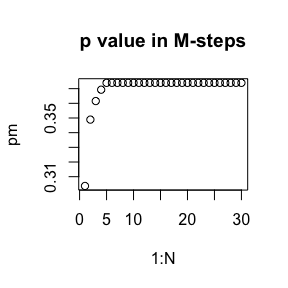

```r
plot(1:N,pm,main = "p value in M-steps")
```

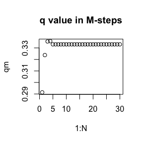

```r
plot(1:N,qm,main = "q value in M-steps")
```

**Homework-2019-12-13**

Use both for loops and lapply() to fit linear models to the mtcars using the formulas stored in this list:

formulas <- list(

mpg ~ disp,

mpg ~ I(1 / disp),

mpg~disp+wt,

mpg~I(1/disp)+wt

)

##Answer

```r
data("mtcars")
mpg<-mtcars$mpg
disp<-mtcars$disp
wt<-mtcars$wt
formulas <- list(

mpg ~ disp,

mpg ~ I(1 / disp),

mpg~disp+wt,

mpg~I(1/disp)+wt
)
A1<-lapply(formulas,lm)
A1
```

```
## [[1]]
##
## Call:
## FUN(formula = X[[i]])
##
## Coefficients:
## (Intercept)         disp
##    29.59985     -0.04122
##
##
## [[2]]
##
## Call:
## FUN(formula = X[[i]])
##
## Coefficients:
## (Intercept)    I(1/disp)
##       10.75      1557.67
##
##
## [[3]]
##
## Call:
## FUN(formula = X[[i]])
##
## Coefficients:
## (Intercept)         disp           wt
##    34.96055     -0.01772     -3.35083
##
##
## [[4]]
##
## Call:
## FUN(formula = X[[i]])
##
## Coefficients:
## (Intercept)    I(1/disp)           wt
##      19.024     1142.560       -1.798
```

##Question2 4.

Fit the model mpg ~ disp to each of the bootstrap replicates of mtcars in the list below by using a for loop and lapply(). Can you do it without an anonymous function?

bootstraps <- lapply(1:10, function(i) {

rows <- sample(1:nrow(mtcars), rep = TRUE)

mtcars[rows, ]

})

##Answer

```r
data("mtcars")
bootstraps <- lapply(1:10, function(i) {

rows <- sample(1:nrow(mtcars), rep = TRUE)

mtcars[rows, ]

})
A2<-lapply(bootstraps,lm, formula=mpg~disp)
A2
```

```
## [[1]]
##
## Call:
## FUN(formula = ..1, data = X[[i]])
##
## Coefficients:
## (Intercept)         disp
##    30.58588     -0.04681
##
##
## [[2]]
##
## Call:
## FUN(formula = ..1, data = X[[i]])
##
## Coefficients:
## (Intercept)         disp
##    28.82907     -0.03695
##
##
## [[3]]
##
## Call:
## FUN(formula = ..1, data = X[[i]])
##
## Coefficients:
## (Intercept)         disp
##     31.3499      -0.0434
##
##
## [[4]]
##
## Call:
## FUN(formula = ..1, data = X[[i]])
##
## Coefficients:
## (Intercept)         disp
##    29.55028     -0.04405
##
##
```

[output cut: 43 more lines]

```
## FUN(formula = ..1, data = X[[i]])
##
## Coefficients:
## (Intercept)         disp
##    30.11546     -0.04192
##
##
## [[10]]
##
## Call:
## FUN(formula = ..1, data = X[[i]])
##
## Coefficients:
## (Intercept)         disp
##    28.66587     -0.03899
```

##Question3

For each model in the previous two exercises, extract R2 using the function below. rsq <- function(mod) summary(mod)$r.squared

##Answer

```r
rsq <- function(mod) summary(mod)$r.squared
lapply(A1, rsq)
```

```
## [[1]]
## [1] 0.7183433
##
## [[2]]
## [1] 0.8596865
##
## [[3]]
## [1] 0.7809306
##
## [[4]]
## [1] 0.8838038
```

```r
lapply(A2, rsq)
```

```
## [[1]]
## [1] 0.7674728
##
## [[2]]
## [1] 0.7022628
##
## [[3]]
## [1] 0.6444917
##
## [[4]]
## [1] 0.6711327
##
## [[5]]
## [1] 0.7949913
##
## [[6]]
## [1] 0.6703221
##
## [[7]]
## [1] 0.800282
##
## [[8]]
## [1] 0.7847992
##
## [[9]]
## [1] 0.7517604
##
## [[10]]
## [1] 0.7306875
```

##Question4

3. The following code simulates the performance of a t-test for non-normal data. Use sapply() and an anonymous function to extract the p-value from every trial. trials <- replicate( 100, t.test(rpois(10, 10), rpois(7, 10)), simplify = FALSE ) Extra challenge: get rid of the anonymous function by using [[ directly.

##Answer

```r
 trials <- replicate( 100,
t.test(rpois(10, 10), rpois(7, 10)),
         simplify = FALSE
       )
sapply(trials,function(x) {
  unlist(x)[3]
})
```

```
##               p.value               p.value               p.value
##   "0.847562655194149"   "0.382305649356498"   "0.800139767259442"
##               p.value               p.value               p.value
##   "0.384567741766125"   "0.370295297705658"   "0.819592718041977"
##               p.value               p.value               p.value
##   "0.746284211813992"    "0.24806243301329"   "0.463776116656894"
##               p.value               p.value               p.value
##   "0.139956025404264"    "0.43722908433003"   "0.312987526837881"
##               p.value               p.value               p.value
##   "0.892287874406301"   "0.221082347915794"   "0.506171665167586"
##               p.value               p.value               p.value
##   "0.983127524253794"    "0.58609142932292"  "0.0209186640969786"
##               p.value               p.value               p.value
##    "0.55043649858367"  "0.0270298911904552"    "0.31872219068121"
##               p.value               p.value               p.value
##   "0.423809538924828"   "0.341963494524273"   "0.703706287654544"
##               p.value               p.value               p.value
##   "0.225858000225149"   "0.435404229802023"   "0.496982594744584"
##               p.value               p.value               p.value
##   "0.912093880324107"   "0.975065900472891"   "0.243849397662702"
##               p.value               p.value               p.value
##   "0.840039302144961"   "0.221518662603481"   "0.550221081866536"
##               p.value               p.value               p.value
##   "0.150282611013427"   "0.959780802822687"     "0.8060860870411"
##               p.value               p.value               p.value
##   "0.425287024941974"   "0.794884899004654" "0.00593651966662788"
##               p.value               p.value               p.value
##   "0.908873199542607"    "0.81039327778566"   "0.655686452580949"
##               p.value               p.value               p.value
##   "0.806385695243762"   "0.872179474957046"  "0.0155373292352864"
##               p.value               p.value               p.value
##   "0.724231787232566"   "0.499985528741221"   "0.525933744127452"
##               p.value               p.value               p.value
##   "0.526701726543687"   "0.957971248345383"   "0.300296318592586"
##               p.value               p.value               p.value
##  "0.0688591157959878"  "0.0920197795954659"   "0.325400123670891"
##               p.value               p.value               p.value
##   "0.860457956272958"   "0.133503579871491"  "0.0628394060472739"
##               p.value               p.value               p.value
##   "0.054241790528616"  "0.0452485812293123"   "0.904850289755035"
```

[output cut: 13 more lines]

```
##   "0.130339135325017"   "0.404700625361549"    "0.50499859227481"
##               p.value               p.value               p.value
##   "0.390134229956637"   "0.508486656227278"   "0.742581517578163"
##               p.value               p.value               p.value
##   "0.192525419255004"   "0.294644998002292"   "0.105155127034481"
##               p.value               p.value               p.value
##   "0.699507040437785"   "0.543816659494918"   "0.187725194594076"
##               p.value               p.value               p.value
##    "0.81381412642056"   "0.107813749592969"    "0.91133199472193"
##               p.value               p.value               p.value
##   "0.658773578407501"   "0.279224169521121"   "0.563365876354503"
##               p.value               p.value               p.value
##   "0.530521336899704"   "0.777568661177252"   "0.784319774198806"
##               p.value
##   "0.788576644278263"
```

```r
##Extra challenge: get rid of the anonymous function by using [[ directly.

sapply(trials, '[[', 3)
```

```
##   [1] 0.84756266 0.38230565 0.80013977 0.38456774 0.37029530 0.81959272
##   [7] 0.74628421 0.24806243 0.46377612 0.13995603 0.43722908 0.31298753
##  [13] 0.89228787 0.22108235 0.50617167 0.98312752 0.58609143 0.02091866
##  [19] 0.55043650 0.02702989 0.31872219 0.42380954 0.34196349 0.70370629
##  [25] 0.22585800 0.43540423 0.49698259 0.91209388 0.97506590 0.24384940
##  [31] 0.84003930 0.22151866 0.55022108 0.15028261 0.95978080 0.80608609
##  [37] 0.42528702 0.79488490 0.00593652 0.90887320 0.81039328 0.65568645
##  [43] 0.80638570 0.87217947 0.01553733 0.72423179 0.49998553 0.52593374
##  [49] 0.52670173 0.95797125 0.30029632 0.06885912 0.09201978 0.32540012
##  [55] 0.86045796 0.13350358 0.06283941 0.05424179 0.04524858 0.90485029
##  [61] 0.43071005 0.82313685 0.84980792 0.37161614 0.02157863 0.85689409
##  [67] 0.73538096 0.63811899 0.96765451 0.13099279 0.98887385 0.57417377
##  [73] 0.98729941 0.93246431 0.66603790 0.28769194 0.47671357 0.79956219
##  [79] 0.13033914 0.40470063 0.50499859 0.39013423 0.50848666 0.74258152
##  [85] 0.19252542 0.29464500 0.10515513 0.69950704 0.54381666 0.18772519
##  [91] 0.81381413 0.10781375 0.91133199 0.65877358 0.27922417 0.56336588
##  [97] 0.53052134 0.77756866 0.78431977 0.78857664
```

##Question5